# Hjemmeopgave 2 - Matematik 1a

#### s183710

#### 27-10-2024

## Opgave a)

Find samtlige komplekse løsninger til ligningen $e^{2z} = 2 + i$.

For at finde alle komplekse løsninger $ z $ til ligningen

$$ e^{2z} = 2 + i $$

kan vi gøre følgende:

**Vi starter med at tage den naturlige logaritme på begge sider:**

$$ 2z = \ln(2 + i) $$

Derfor,

$$ z = \frac{\ln(2 + i)}{2} $$

**Vi konverterer $ 2 + i $ til polær form:**

Et komplekst tal $ w = a + bi $ kan skrives i polær form som

$$ w = r e^{i\theta} $$

hvor modulus er

$$ r = |w| = \sqrt{a^2 + b^2} $$

og argumentet

$$ \theta = \arg(w) = \tan^{-1}\left(\frac{b}{a}\right) $$

**For $ 2 + i $:**

*Modulus:*

$$ r = \sqrt{2^2 + 1^2} = \sqrt{5}. $$

*Argument:*

$$ \theta = \tan^{-1}\left(\frac{1}{2}\right) $$

Derfor er de polære koordinater til $2+i$:

$$ 2 + i = \sqrt{5} \, e^{i \tan^{-1}\left(\frac{1}{2}\right)} $$

**Vi beregner den naturlige logaritme:**

Logaritmen af et komplekst tal i polær form er givet ved:

$$ \ln(re^{i\theta}) = \ln r + i (\theta + 2k\pi) $$

Anvender vi dette på $ 2 + i $:

$$ \ln(\sqrt{5} \, e^{i \tan^{-1}\left(\frac{1}{2}\right)}) = \ln(\sqrt{5}) + i \left( \tan^{-1}\left(\frac{1}{2}\right) + 2k\pi \right) $$

**Løs for $ z $:**

Sæt det tilbage i udtrykket for $ z $:

$$ z = \frac{1}{2} \ln(\sqrt{5}) + \frac{i}{2} \left( \tan^{-1}\left(\frac{1}{2}\right) + 2k\pi \right) $$

Vi simplificerer:

$$ z = \frac{1}{4} \ln 5 + i \left( \frac{1}{2} \tan^{-1}\left(\frac{1}{2}\right) + k\pi \right) $$

**Endeligt svar:**

Alle komplekse løsninger er givet ved

$$ \boxed{z = \frac{1}{4} \ln 5 + i \left( \frac{\tan^{-1}\left(\frac{1}{2}\right)}{2} + k\pi \right)} $$

hvor $ k $ er vilkårligt helt tal.

## Opgave b)

Givet to komplekse tal $z_1$ og $z_2$. Det oplyses at $Arg(z_1) = π/4$ og $Arg(z_2) = 3$. Bestem $Arg(−2z_1^4/z_2^{10})$.

Vi bruger Sætning 3.6.2 som siger at argumentet til en brøk er argumentet til tælleren minus argumentet til nævneren, og at argumentet til et produkt er summen af argumenterne. $$Arg(-2z_1^4/z_2^{10}) = Arg(-2)+Arg(z_1^4)-Arg(z_2^{10})$$

Vi ved at $Arg(-2) = π$, og vi bruger reglen om at argumentet til en potens er eksponenten gange argumentet til grundtallet. $$= \pi + 4 \cdot Arg(z_1) - 10 \cdot Arg(z_2)$$

Vi indsætter de givne værdier for argumenterne: $Arg(z₁) = π/4$ og $Arg(z₂) = 3$ $$=\pi + 4 \cdot \frac{\pi}{4} - 10 \cdot 3$$

Vi regner ud at $4 · π/4 = π$ og $10 · 3 = 30$ $$=\pi+\pi-30\\$$ $$=2\pi-30 $$

Da hovedargumentet ligger i intervallet $[-\pi, \pi]$, kan vi lægge $2π$ til indtil vi er inde i intervallet:

\begin{align} 2 \pi - 30 + 2 \pi &= 4 \pi - 30 < -\pi \\ 4 \pi - 30 + 2 \pi &= 6 \pi - 30 < -\pi \\ 6 \pi - 30 + 2 \pi &= 8 \pi - 30 < -\pi \\ 8 \pi - 30 + 2 \pi &= 10 \pi - 30 > -\pi\\ \end{align}

Det endelige hovedargument er derfor: $$ \boxed{10 \pi - 30 ≈ 1.416} $$

## Opgave c)

Afgør ved hjælp af divisionsalgoritmen om polynomiet $d(Z) = Z^2 − 3Z + 2$ går op i polynomiet $p(Z) = Z^5 − 3Z^4 + Z^3 + 4$.

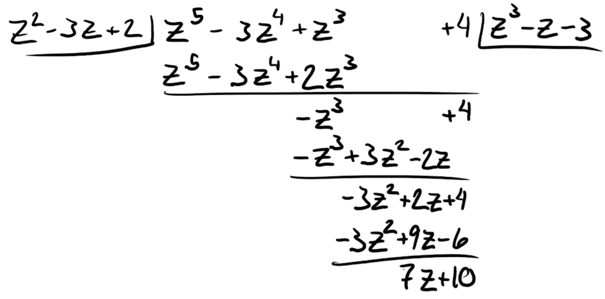

Da resten ikke er nul, kan vi konkludere, at: $$ \boxed{Z^2 - 3Z + 2 \text{ går ikke op i } Z^5 - 3Z^4 + Z^3 + 4 }$$

## Opgave d)

1. Vis at tallet −3 er en rod i polynomiet $Z^3 − Z^2 + 36$. Hvad er rodens multiplicitet?
2. Bestem samtlige rødder i $Z^3 − Z^2 + 36$.

### 1.

Vi udfører igen divisionsalgoritmen:

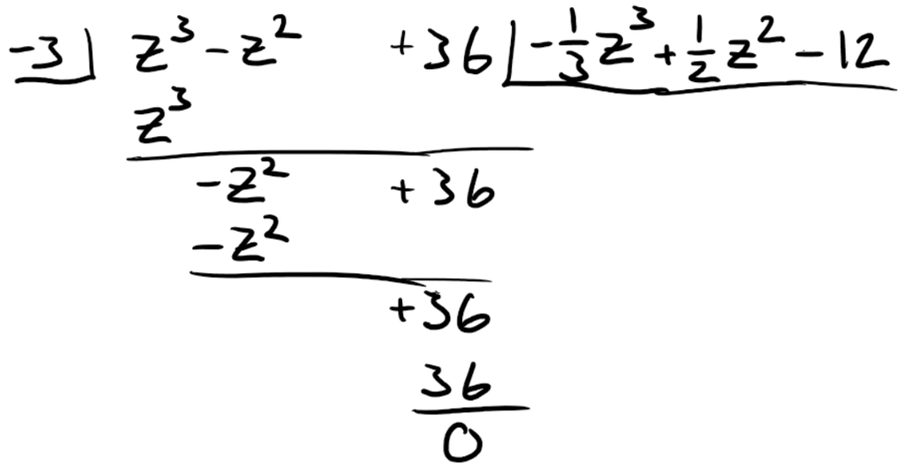

Den nemmeste måde at se om $-3$ er rod i denne opgave havde været at indsætte $-3$ på Z's plads i polynomiet og udregnede det:

$$ -3^3-(-3)^2+36=-27-9+36=0 $$

Det er i dette tilfælde ligetil, da $deg(d(Z)=-3)=0$.

Når vi har en rod $r$, så er $(Z-r)$ en faktor i polynomiet. I dette tilfælde er $r = -3$, så faktoren bliver $(Z-(-3)) = (Z+3)$.

For at finde multipliciten skal vi undersøge hvor mange gange $(Z+3)$ går op i polynomiet. Vi kan bruge polynomisk division til at dividere $Z^3 − Z^2 + 36$ med $(Z+3)$. Vi får:

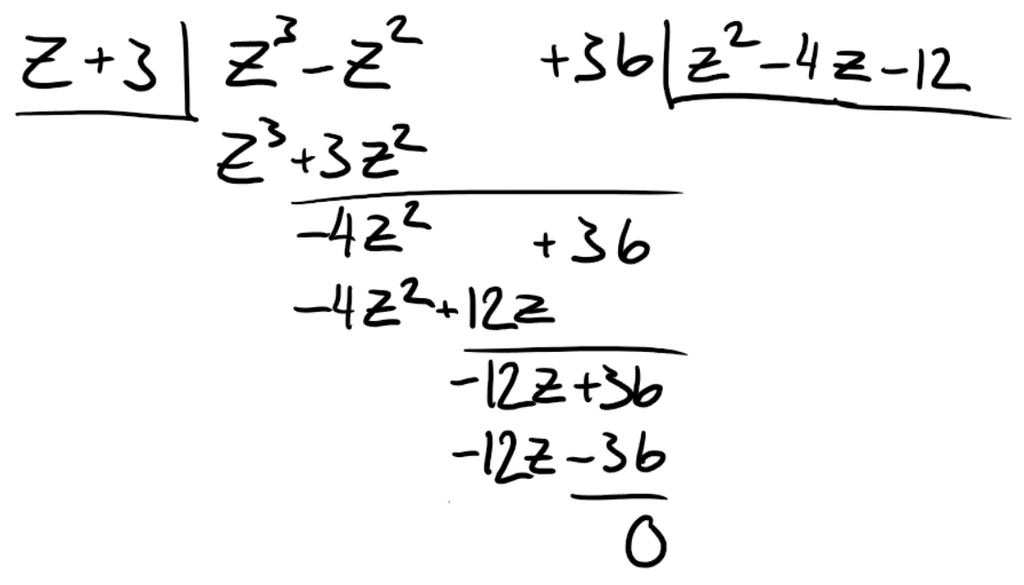

Da divisionen går op uden rest, er multipliciteten mindst 1. Vi undersøger videre for at afgøre om multiplicitetten skulle være højere.

Vi kan tjekke om $(Z+3)$ går op i $Z^2-4Z-12$:

Vi indsætter $Z = -3$ i $Z^2-4Z-12$: $$(-3)^2-4(-3)-12$$ $$9+12-12$$ $$9 ≠ 0$$

Da $(Z+3)$ ikke går op i $Z^2-4Z-12$, betyder det at $-3$ kun er rod én gang.

Derfor er multipliciten af roden -3 lig med $\boxed{1}$.

### 2.

Bestem samtlige rødder i $Z^3 − Z^2 + 36$.

## Opgave e)

Funktionen $f : \mathbb{N} → \mathbb{Z}$ opfylder at $$ f(n) = \begin{cases} 2 & \text{hvis } n = 1 \\ f(n-1)^2 - (n-1)^2 & \text{hvis } n \geq 2 \end{cases} $$

Beregn $f(n)$ for $n \in \{1, 2, 3, 4, 5\}$.

Vi beregner: \begin{align} f(1) &= 2 \\ f(2) &= f(1)^2 - (2-1)^2 = 2^2 - 1^2 = 4 - 1 = 3 \\ f(3) &= f(2)^2 - (3-1)^2 = 3^2 - 2^2 = 9 - 4 = 5 \\ f(4) &= f(3)^2 - (4-1)^2 = 5^2 - 3^2 = 25 - 9 = 16 \\ f(5) &= f(4)^2 - (5-1)^2 = 16^2 - 4^2 = 256 - 16 = 240 \end{align}

Sammenfattende er værdierne for $f(n)$ som følger:

$$\boxed{f(1) = 2, \ f(2) = 3, \ f(3) = 5, \ f(4) = 16, \ f(5) = 240}$$

## Opgave f)

Lad $r$ og $s$ være to forskellige komplekse tal. Vis ved hjælp af induktion efter $n$ at $$ r^n + r^{n-1} \cdot s + r^{n-2} \cdot s^2 + ... + r \cdot s^{n-1} + s^n = \frac{r^{n+1} - s^{n+1}}{r - s} $$ for alle $n \in \mathbb{N}$.

Lad os løse dette induktionsbevis trin for trin.

Først tjekker vi, at formlen holder for $n = 1$:

For $n = 1$ har vi venstre side: $$r + s$$ Højre side: $$( \frac{r^2 - s^2}{r - s} = \frac{(r+s)(r-s)}{r-s} = r + s )$$ Så formlen holder for $n = 1$.

Vi antager nu at formlen holder for et vilkårligt $k \in \mathbb{N}$ (induktionsantagelsen):

$$r^k + r^{k-1}s + r^{k-2}s^2 + \ldots + rs^{k-1} + s^k = \frac{r^{k+1} - s^{k+1}}{r - s}$$

Vi skal vise at formlen så også holder for $k+1$.

Venstre side for $k+1$ er: $$r^{k+1} + r^k s + r^{k-1} s^2 + \ldots + r s^k + s^{k+1}$$ Dette kan omskrives til: $$r(r^k + r^{k-1} s + r^{k-2} s^2 + \ldots + r s^{k-1} + s^k) + s^{k+1}$$ Ved at bruge induktionsantagelsen får vi:

$$r\left(\frac{r^{k+1} - s^{k+1}}{r - s}\right) + s^{k+1}$$$$= \frac{r^{k+2} - r s^{k+1}}{r - s} + s^{k+1}$$$$= \frac{r^{k+2} - r s^{k+1} + s^{k+1}(r - s)}{r - s}$$$$= \frac{r^{k+2} - s^{k+2}}{r - s}$$

Dette er netop formlen for $k+1$, så induktionsbeviset er fuldført.

Derfor gælder formlen for alle $n \in \mathbb{N}$.